# TEMPEST: Porewater ICP

Run 2 - 2026/04/17

2023-2025 Samples

2026-08-27

#SET UP

#USEFUL FUNCTIONS

# April 17, 2026 - Run 2

## Metal Standard Curve Checks

### Lower (0.01 ppm) standard added

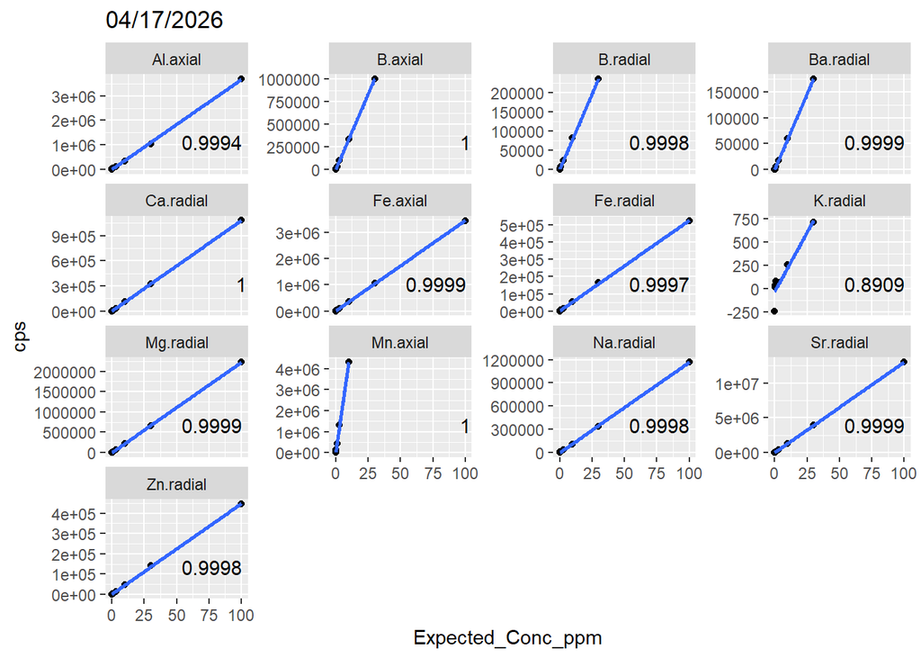

**TABLE OF CALIBRATION CURVE VALUES**

Red values are <0.999

| Element | slope | intercept | R2 | Run_Date |
| --- | --- | --- | --- | --- |
| Al.axial | 36985.14555 | -13983.02987 | 0.99944 | 04/17/2026 |
| B.axial | 33515.52472 | -625.44527 | 0.99999 | 04/17/2026 |
| B.radial | 7852.03623 | 135.87444 | 0.99982 | 04/17/2026 |
| Ba.radial | 5839.36517 | 115.61527 | 0.99989 | 04/17/2026 |
| Ca.radial | 10807.92822 | 1754.36365 | 0.99997 | 04/17/2026 |
| Fe.axial | 34615.24068 | 4656.79255 | 0.99992 | 04/17/2026 |
| Fe.radial | 5253.04700 | 780.98665 | 0.9997 | 04/17/2026 |
| K.radial | 25.58539 | -30.99644 | 0.89093 | 04/17/2026 |
| Mg.radial | 22301.95552 | -3991.52627 | 0.99992 | 04/17/2026 |
| Mn.axial | 431673.80483 | 4445.05257 | 0.99995 | 04/17/2026 |
| Na.radial | 11711.46524 | -4198.68427 | 0.99982 | 04/17/2026 |
| Sr.radial | 130229.04460 | 10882.21771 | 0.99994 | 04/17/2026 |
| Zn.radial | 4475.23501 | 578.02111 | 0.99975 | 04/17/2026 |

## P, S, and Si Standard Curve Checks

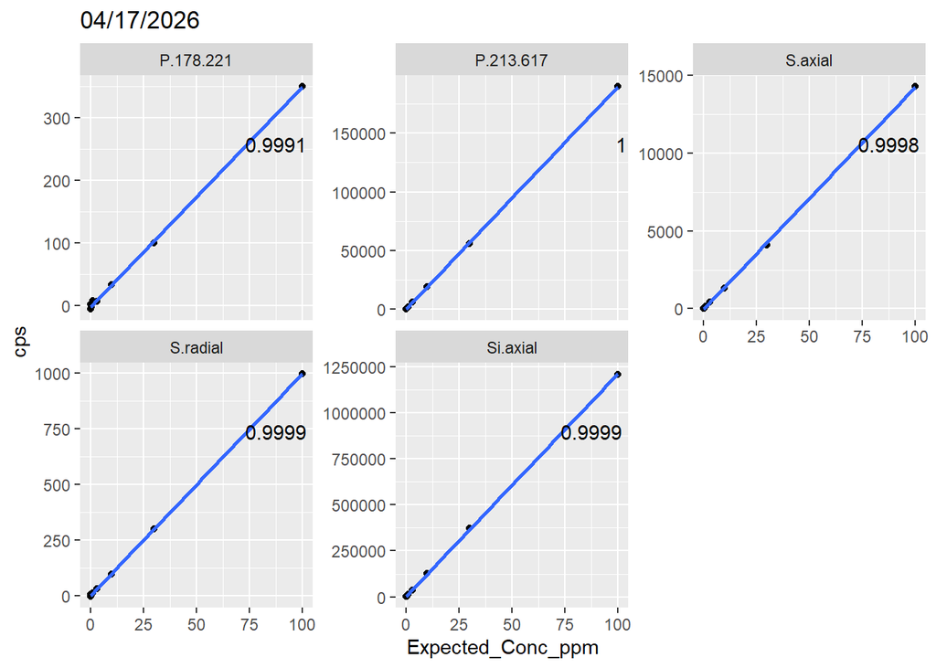

**TABLE OF CALIBRATION CURVE VALUES**

Red values are <0.999

| Element | slope | intercept | R2 | Run_Date |
| --- | --- | --- | --- | --- |
| P.178.221 | 3.49868 | -1.32193 | 0.99911 | 04/17/2026 |
| P.213.617 | 1895.34139 | -1.34359 | 0.99997 | 04/17/2026 |
| S.axial | 142.67229 | -35.98531 | 0.99975 | 04/17/2026 |
| S.radial | 9.96287 | 0.87225 | 0.9999 | 04/17/2026 |
| Si.axial | 12083.95243 | 2019.43593 | 0.99994 | 04/17/2026 |

#Import sample data

## Counts

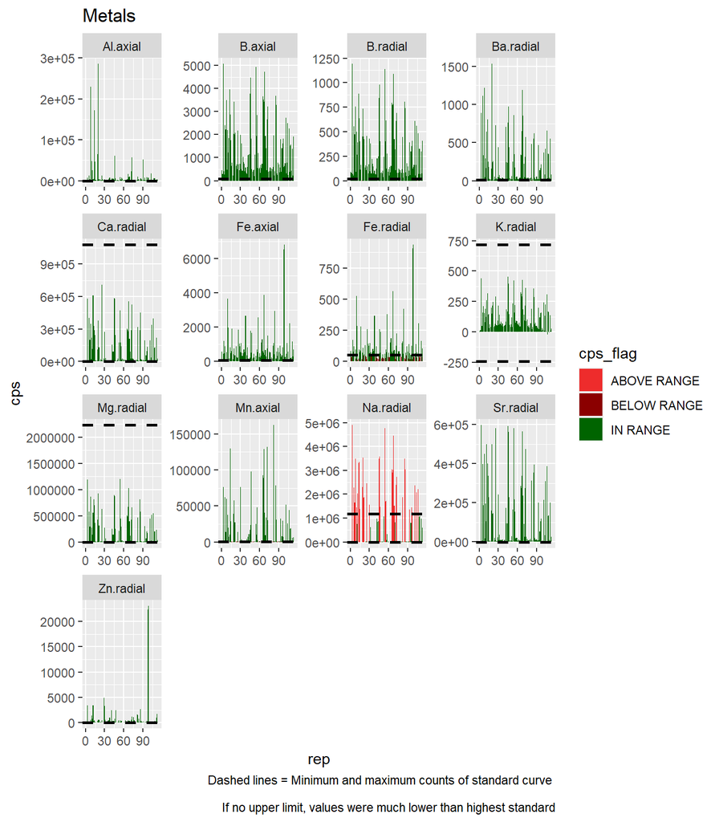

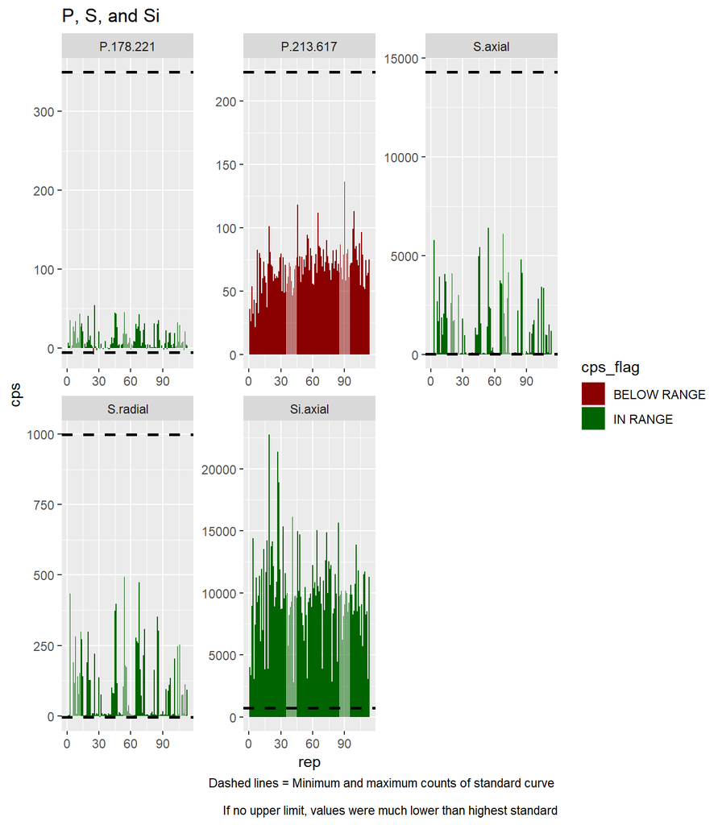

Red elements had <80% of samples within range of standard curve

| Element | Pass_percent | range_flag |
| --- | --- | --- |
| Al.axial | 100.0 | PASS |
| B.axial | 100.0 | PASS |
| B.radial | 98.2 | PASS |
| Ba.radial | 96.5 | PASS |
| Ca.radial | 95.6 | PASS |
| Fe.axial | 97.3 | PASS |
| Fe.radial | 60.2 | FAIL |
| K.radial | 100.0 | PASS |
| Mg.radial | 100.0 | PASS |
| Mn.axial | 51.3 | FAIL |
| Na.radial | 67.3 | FAIL |
| P.178.221 | 99.1 | PASS |
| P.213.617 | 0.0 | FAIL |
| S.axial | 85.8 | PASS |
| S.radial | 100.0 | PASS |
| Si.axial | 100.0 | PASS |
| Sr.radial | 100.0 | PASS |
| Zn.radial | 100.0 | PASS |

## Asses Metal Check Standards

### M 1 ppm Checks

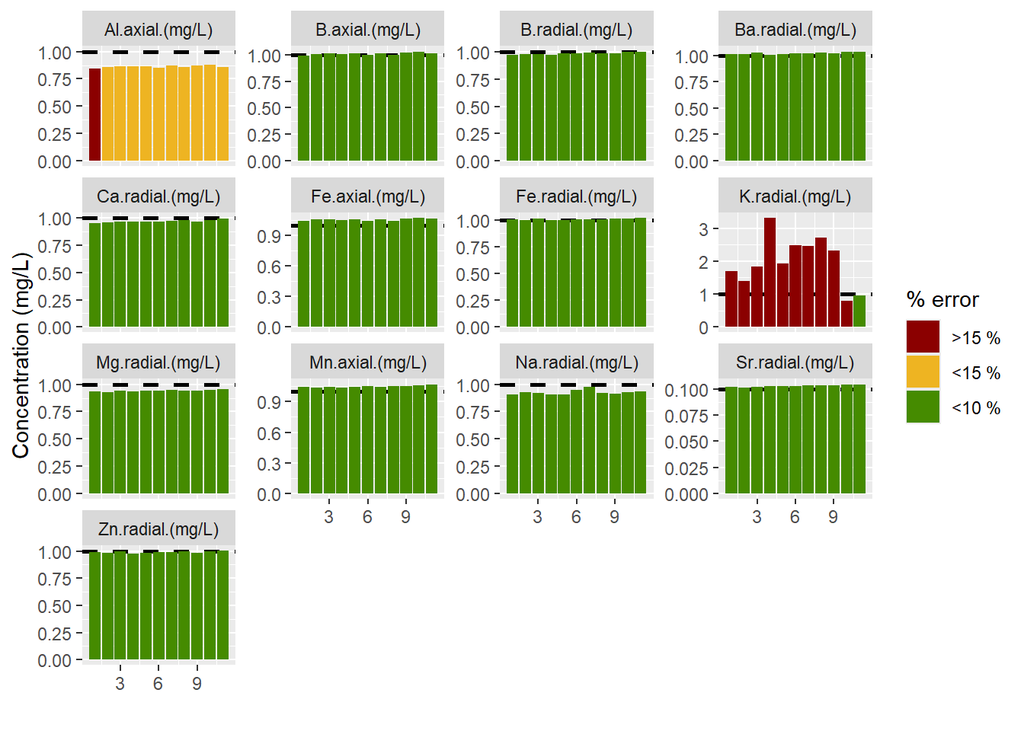

**LIST OF ELEMENTS WITH <80% OF CHECK STANDARDS WITHIN 15% OF EXPECTED CONCENTRATION - REASSESS**

| Element |
| --- |
| K.radial |

### M 0.01 ppm Checks to test precision at low concentrations

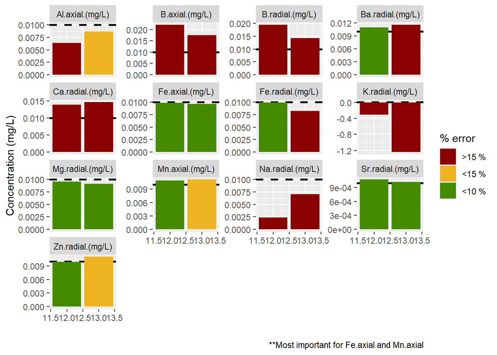

**<80% OF CHECK STANDARDS WITHIN 15% OF EXPECTED CONCENTRATION AT LOW CONCENTRATION - REASSESS**

| Element |
| --- |
| Al.axial |
| B.axial |
| B.radial |
| Ba.radial |
| Ca.radial |
| Fe.radial |
| K.radial |
| Na.radial |

## Assess P, S, and Si Check Standards

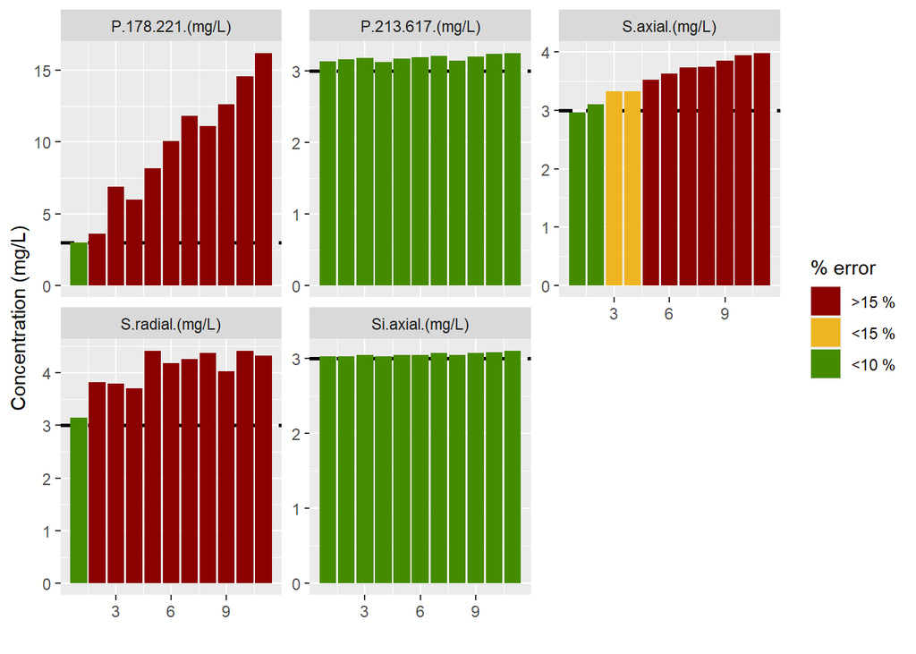

**LIST OF ELEMENTS WITH <80% OF CHECK STANDARDS WITHIN 15% OF EXPECTED CONCENTRATION - REASSESS**

| Element |
| --- |
| P.178.221 |
| S.axial |
| S.radial |

## Check Internal Standards

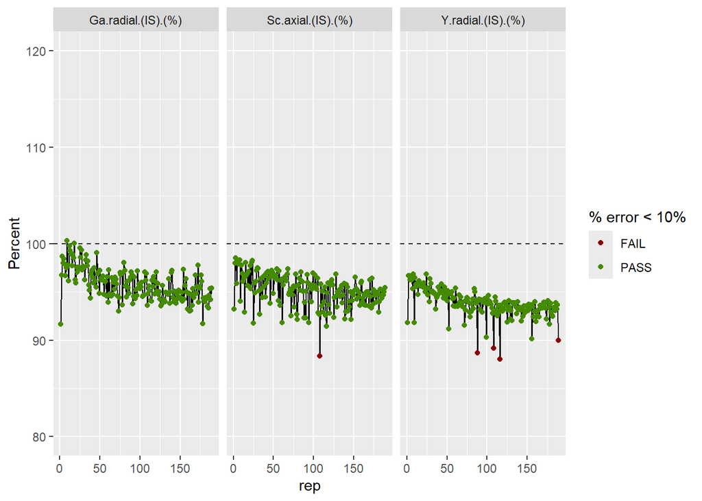

99.1181657848324 % of Internal Standards measurements are within 10% of 100

**Samples with low internal standard**[[1]] [1] “TMP_SW_H3_20230607_PM” “TMP_SW_C3_20240617_spk” “TMP_SW_C3_20240617_spk” [4] “TMP_SW_B4_20230607_AM” “TMP_SW_B4_20230807_RA”

## Additional Checks

### NIST 1643f and Multi-elemental standard (QCS) are used as additional checks with a 10x dilution

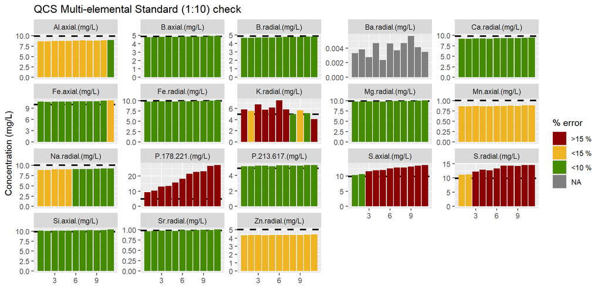

**LIST OF ELEMENTS WITH <80% OF CHECK STANDARDS WITHIN 15% OF EXPECTED CONCENTRATION - REASSESS**

| Element | Avg % Error |
| --- | --- |
| K.radial | 18.99 |
| P.178.221 | 269.69 |
| S.axial | 23.28 |
| S.radial | 33.34 |

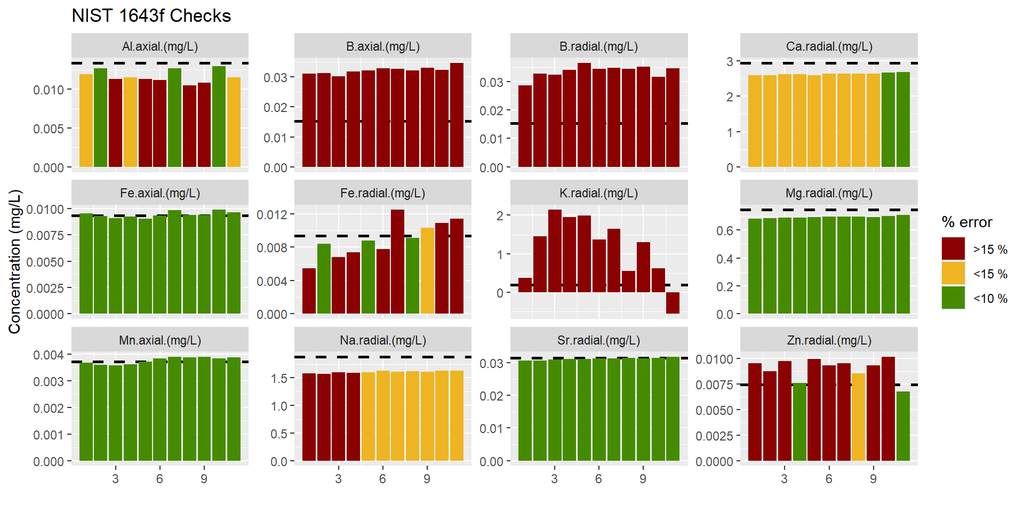

**LIST OF ELEMENTS WITH <80% OF NIST CHECKS WITHIN 15% OF EXPECTED CONCENTRATION - REASSESS**

| Element | Avg % Error |
| --- | --- |
| Al.axial | 12.75 |
| B.axial | 111.49 |
| B.radial | 120.52 |
| Fe.radial | 18.92 |
| K.radial | 575.49 |
| Na.radial | 14.63 |
| Zn.radial | 23.07 |

### Duplicate samples

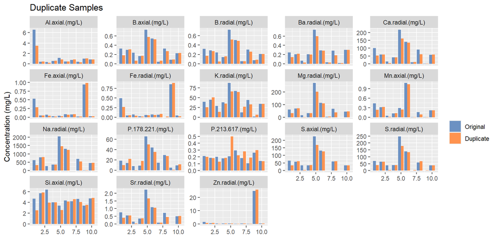

**LIST OF ELEMENTS WITH <80% OF DUPLICATE SAMPLES WITHIN 15% OF SAMPLE CONCENTRATION - REASSESS**

| Element | Avg % Difference |
| --- | --- |
| Al.axial | 18.85 |
| B.axial | 26.67 |
| B.radial | 27.96 |
| Ba.radial | 23.31 |
| Ca.radial | 26.00 |
| Fe.axial | 21.19 |
| Fe.radial | 46.52 |
| K.radial | 38.57 |
| Mg.radial | 32.44 |
| Mn.axial | 28.41 |
| Na.radial | 33.67 |
| P.178.221 | 78.73 |
| P.213.617 | 28.08 |
| S.axial | 30.00 |
| S.radial | 50.01 |
| Si.axial | 16.96 |
| Sr.radial | 28.03 |
| Zn.radial | 31.79 |

### Sample Spikes

*Samples spiked with 0.2 mL of LFB (M10)*

*Spiked samples with > DF 3.5 removed due to poor accuracy*

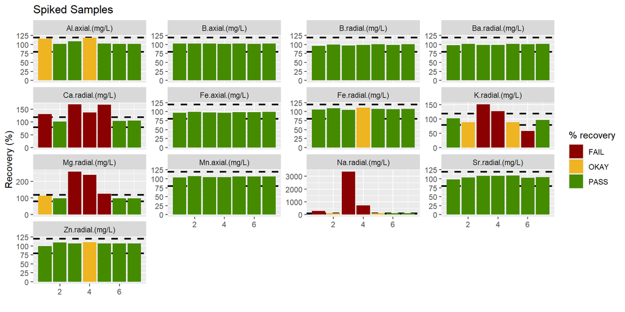

**LIST OF ELEMENTS WITH <80% OF SPIKED SAMPLES WITH 100 (+/- 20%) PERCENT RECOVERY - REASSESS**

| Element | Avg % Recovery |
| --- | --- |
| Ca.radial.(mg/L) | 131.32 |
| K.radial.(mg/L) | 101.49 |
| Mg.radial.(mg/L) | 148.18 |
| Na.radial.(mg/L) | 683.25 |

# **Summary of QA/QC Results**

*Red elements did not pass QA/QC Checks*

Element must pass either NIST or QCS checks AND check standards

| Element | Number of Checks | Fail (%) | Passed_checks | Failed_checks | QAQC |
| --- | --- | --- | --- | --- | --- |
| Al.axial | 5 | 40 | range, chk , QCS | NIST, dup | PASS |
| B.axial | 5 | 40 | range, chk , QCS | NIST, dup | PASS |
| B.radial | 5 | 40 | range, chk , QCS | NIST, dup | PASS |
| Ba.radial | 3 | 33 | range, chk | dup | FAIL |
| Ca.radial | 5 | 20 | range, chk , NIST , QCS | dup | PASS |
| Fe.axial | 5 | 20 | range, chk , NIST , QCS | dup | PASS |
| Fe.radial | 5 | 60 | chk, QCS | range, NIST , dup | PASS |
| K.radial | 5 | 80 | range | chk , NIST, QCS , dup | FAIL |
| Mg.radial | 5 | 20 | range, chk , NIST , QCS | dup | PASS |
| Mn.axial | 5 | 40 | chk , NIST, QCS | range, dup | PASS |
| Na.radial | 5 | 60 | chk, QCS | range, NIST , dup | PASS |
| P.178.221 | 4 | 75 | range | chk, QCS, dup | FAIL |
| P.213.617 | 4 | 50 | chk, QCS | range, dup | PASS |
| S.axial | 4 | 75 | range | chk, QCS, dup | FAIL |
| S.radial | 4 | 75 | range | chk, QCS, dup | FAIL |
| Si.axial | 4 | 25 | range, chk , QCS | dup | PASS |
| Sr.radial | 5 | 20 | range, chk , NIST , QCS | dup | PASS |
| Zn.radial | 5 | 40 | range, chk , QCS | NIST, dup | PASS |

# Sample Processing Steps

1. Sample concentrations were compared to blank concentrations. If sample concentration < blank concentration, then the sample concentration was set to zero.
2. Dilution factor was applied to each sample. In most cases, DF=5
3. Flags added to elments that had a poor standard curve.
4. Elements that did not pass QAQC were removed from the dataset
5. Removed samples that had low internal standards (<90%)
6. Column added to data listing elements that did not pass QAQC
7. Data exported to .csv

# Preliminary Plot of Data

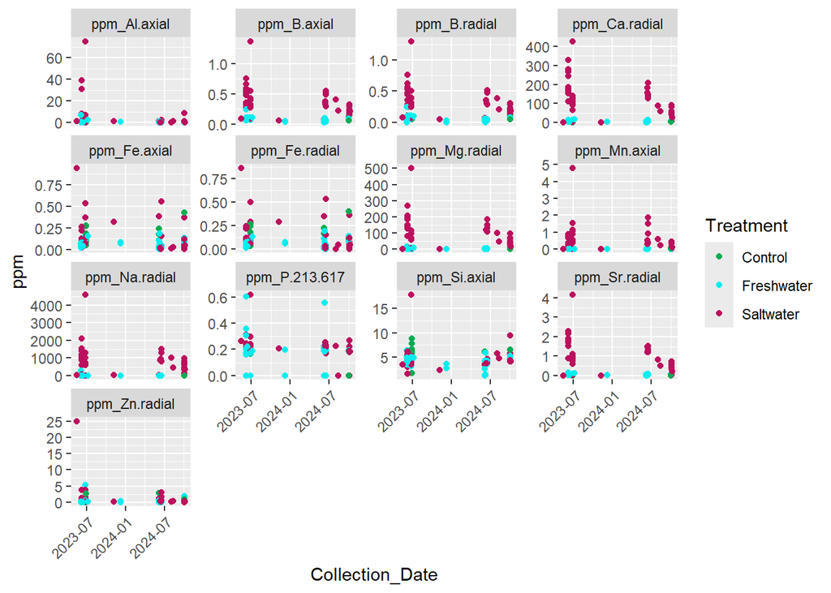